# STAT462 Assignment 2: Classification

Graham Greig SN: 47022356

09/09/2021

# Problem 1

*Suppose we collect data for a group of students with variables $X1$ = hours spent studying per week, $X2$ = number of classes attended and Y = (1 if the student received a GPA value of 7 or better in in the class and 0 otherwise.) We fit a logistic regression model and find the estimated coefficients to be: $\hat{\beta_0} = -16;$ $\hat{\beta_1} = 1.4$ and $\hat{\beta_2} = 0.3$.*

*a.) Estimate the probability that a student gets a GPA value $\geqslant$ 7 if they study 5 or more hours per week and they attend all 36 classes.*

The model for the logistic regression function for this classification problem is:

$$P(Y \geqslant 7 | X1 = 5, X2 = 36) = p(x) = \frac{e^{\hat{\beta_0} + \hat{\beta_1}5 + \hat{\beta_2}36}}{ 1 + e^{\hat{\beta_0} + \hat{\beta_1}5 + \hat{\beta_2}36}}$$

```r
#Start by defining the coefficients
beta_0 = -16
beta_1 = 1.4
beta_2 = 0.3

x1 = 5
x2 = 36

#Now evaluate the function
prob = exp(beta_0 + beta_1 * x1 + beta_2 * x2) / (1 + exp(beta_0 + beta_1 * x1 + beta_2 * x2))
```

The probability if found to be: **85.81%**.

*b.) If a student attends 18 classes how many hours need to be studied to achieve a GPA of greater than or equal to 7 with a probability of 50%*

This is best solved using the logit transform of the logistic regression function

$$log(1) = \hat{\beta_0} + \hat{\beta_1}X1 + \hat{\beta_2}*18$$
And so,

```r
X1 = (-beta_0 - beta_2*18)/beta_1
```

This finds that the student would need to study **7.57** hours per week to have a 50% chance of achieving a GPA of 7 or greater.

# Problem 2

*In this problem a logistic model will be fit to predict the probability that a banknote was forged using the banknote data set. This data has been divided into training and testing sets. (BankTrain.csv and BankTest.csv) The 5th column is the response variable where y = 1 indicates a forgery and y = 0 is a genuine note. Only X1 and X3 will be used as predictors.*

*a.) Perform Multiple Logistic Regression on the training data and comment on the model.*

The model to fit will once again be $p(x) = \frac{e^{\hat{\beta_0} + \hat{\beta_1}X1 + \hat{\beta_3}X3}}{ 1 + e^{\hat{\beta_0} + \hat{\beta_1}X1 + \hat{\beta_3}X3}}$

```r
# Load in the data
BankTrain=read.csv("BankTrain.csv",header=T,na.strings="?")
BankTest=read.csv("BankTest.csv",header=T,na.strings="?")

#Get the model
training_glm=glm(y~x1+x3, data=BankTrain, family=binomial)
summary(training_glm)
```

```
##
## Call:
## glm(formula = y ~ x1 + x3, family = binomial, data = BankTrain)
##
## Deviance Residuals:
##      Min        1Q    Median        3Q       Max
## -2.83187  -0.28343  -0.06417   0.50032   1.99366
##
## Coefficients:
##             Estimate Std. Error z value Pr(>|z|)
## (Intercept)  0.22041    0.11206   1.967   0.0492 *
## x1          -1.31489    0.08822 -14.905  < 2e-16 ***
## x3          -0.21738    0.02880  -7.548 4.42e-14 ***
## ---
## Signif. codes:  0 '***' 0.001 '**' 0.01 '*' 0.05 '.' 0.1 ' ' 1
##
## (Dispersion parameter for binomial family taken to be 1)
##
##     Null deviance: 1322.01  on 959  degrees of freedom
## Residual deviance:  572.07  on 957  degrees of freedom
## AIC: 578.07
##
## Number of Fisher Scoring iterations: 6
```

From the summary it is clear that the P values for x1 and x3 are significant indicating that they should be considered in the model from a maximum likelihood estimation of Bernoulli trials. The intercept however is not very significant. From the p-values in the summary (Pr(>|Z|)) this is likely a good model. The beta values are found to be:

$$\hat{\beta_0} = 0.22, \hat{\beta_1} = -1.31, \hat{\beta_3} = -0.22$$
*b.)* *i.)Plot the training data and the decision boundary assuming a decision boundary of p(x) = 0.5*

For this, the logit form of the GLM classiification is most useful. We get:

$$log(\frac{p(x)}{1 - p(x)}) = \hat{\beta_0} + \hat{\beta_1}X1 + \hat{\beta_3}X3$$
Using $p(x) = 0.5$ gives:

$$X1 = -\frac{\hat{\beta_3}}{\hat{\beta_1}}X3 -\frac{\hat{\beta_0}}{\hat{\beta_1}}$$
This is a model which can have its decision boundary plotted with slope $-\frac{\hat{\beta_3}}{\hat{\beta_1}}$ and intercept $-\frac{\hat{\beta_0}}{\hat{\beta_1}}$.

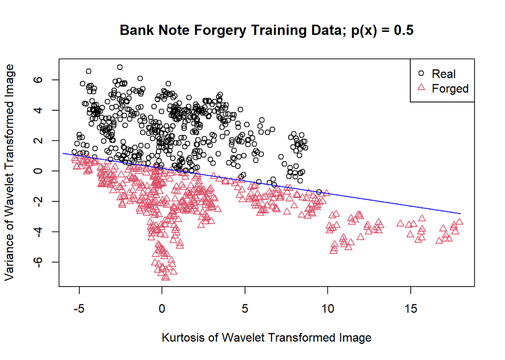

```r
glm_probs = predict(training_glm, type="response")
glm_pred=rep("Real Banknote",960)
glm_pred[glm_probs>.5]="Forged Banknote"
glm_pred = factor(glm_pred, levels = c("Real Banknote", "Forged Banknote"))

plot(BankTrain$x3, BankTrain$x1, pch = as.integer(glm_pred), col = as.integer(glm_pred), main = "Bank Note Forgery Training Data; p(x) = 0.5", xlab = "Kurtosis of Wavelet Transformed Image", ylab = "Variance of Wavelet Transformed Image")
legend("topright",legend = c("Real", "Forged"), pch = c(1,2),col = c(1,2),text.col = "black",horiz = FALSE)

x = seq(from=-6,to=18,0.01)
beta = summary(training_glm)$coef[,1]
y = -beta[3]/beta[2]*x -beta[1]/beta[2]

lines(x,y,col="blue")
```

*ii) Compute the confusion matrix for the Testing data set and comment on the output*

The confusion matrix is computed as follows:

```r
test_probs = predict(training_glm,BankTest,type = "response")
test_glm_pred=rep("Real Banknote",412)
test_glm_pred[test_probs>.5]="Forged Banknote"
test_glm_pred = factor(test_glm_pred, levels = c("Real Banknote", "Forged Banknote"))
table(test_glm_pred,BankTest$y)
```

```
##
## test_glm_pred       0   1
##   Real Banknote   204  24
##   Forged Banknote  32 152
```

The accuracy of this model is found by:

```r
(204 + 152)/412
```

```
## [1] 0.8640777
```

So the model is 86.4% accurate on the test data. This is an alright estimate of forgeries but almost 15% will not be caught by this model. Also, there are almost equal false forgeries (32) and false real notes (24)

*iii.) Using $p(x) = 0.3$ and $p(x) = 0.6$, compute the confusion matrices. Comment when $p(x) = 0.3$ could be desirable.*

Starting with 0.6:

```r
test_probs = predict(training_glm,BankTest,type = "response")
test_glm_pred=rep("Real Banknote",412)
test_glm_pred[test_probs>.6]="Forged Banknote"
test_glm_pred = factor(test_glm_pred, levels = c("Real Banknote", "Forged Banknote"))
table(test_glm_pred,BankTest$y)
```

```
##
## test_glm_pred       0   1
##   Real Banknote   210  35
##   Forged Banknote  26 141
```

```r
(210 + 141)/412
```

```
## [1] 0.8519417
```

Moving to $p(x) = 0.6$ has slightly decreased the accuracy of the model. This has also flipped the proportion of false forgeries and false real notes.

Now with $p(x) = 0.3$

```r
test_probs = predict(training_glm,BankTest,type = "response")
test_glm_pred=rep("Real Banknote",412)
test_glm_pred[test_probs>.3]="Forged Banknote"
test_glm_pred = factor(test_glm_pred, levels = c("Real Banknote", "Forged Banknote"))
table(test_glm_pred,BankTest$y)
```

```
##
## test_glm_pred       0   1
##   Real Banknote   183   5
##   Forged Banknote  53 171
```

```r
(183 + 171)/(412)
```

```
## [1] 0.8592233
```

# Problem 3

*In this problem linear discriminant analysis (LDA) and quadratic discriminant analysis (QDA) models will be fit to the training data set.*

*i.)Perform LDA analysis on the data set*

```r
library(MASS)
lda_fit=lda(y~x1+x3, data=BankTrain)
lda_fit
```

```
## Call:
## lda(y ~ x1 + x3, data = BankTrain)
##
## Prior probabilities of groups:
##         0         1
## 0.5479167 0.4520833
##
## Group means:
##          x1       x3
## 0  2.322977 0.938296
## 1 -1.870594 2.114927
##
## Coefficients of linear discriminants:
##            LD1
## x1 -0.55425154
## x3 -0.07209638
```

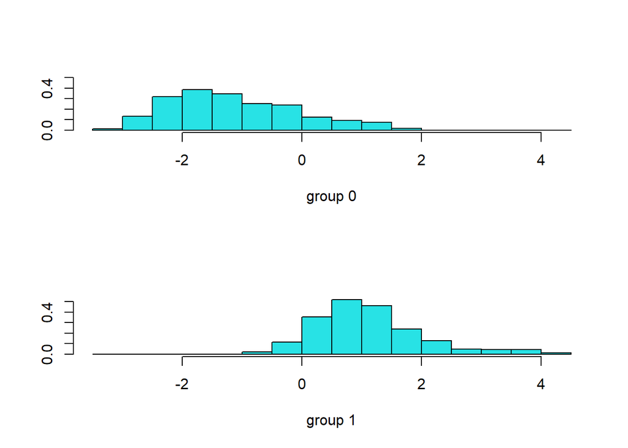

```r
plot(lda_fit)
```

From the prior probabilities we can see that ~54.8% of the training data are real banknotes and ~45.2% are fakes. We see that the data is roughly normal in nature and so this could be a good method of analysis. To determine this, lets look at the confusion matrix.

```r
lda_probs = predict(lda_fit,BankTest,type = "response")
lda_class=lda_probs$class
table(lda_class,BankTest$y)
```

```
##
## lda_class   0   1
##         0 203  22
##         1  33 154
```

```r
mean(lda_class==BankTest$y)
```

```
## [1] 0.8665049
```

This model is 86.7% accurate.

*ii)Repeat using QDA*

```r
qda_fit=qda(y~x1+x3, data=BankTrain)
qda_fit
```

```
## Call:
## qda(y ~ x1 + x3, data = BankTrain)
##
## Prior probabilities of groups:
##         0         1
## 0.5479167 0.4520833
##
## Group means:
##          x1       x3
## 0  2.322977 0.938296
## 1 -1.870594 2.114927
```

```r
qda_class=predict(qda_fit,BankTest)$class
table(qda_class,BankTest$y)
```

```
##
## qda_class   0   1
##         0 208  18
##         1  28 158
```

```r
mean(qda_class==BankTest$y)
```

```
## [1] 0.8883495
```

From the confusion matrix we see that the QDA model is slightly more accurate at 88.8%.

*iii.) Compare with the logistic regression for $p(x) = 0.5$*

Comparing the accuracy of the models we have: QDA: 88.8%, LDA: 86.7% and GLM:86.4%. The LDA and GLM models have pretty similar false positive and false negative rates while the QDA model does slightly better on both which increases its accuracy. Because of this, I would choose to use the QDA model over the other two for its slightly improved accuracy at separating forgeries and real banknotes.

# Problem 4

*Consider a binary classifcation problem $Y \in \{1,0\}$; 1g with one predictor $X$. Assume that $X$ is normally distributed in each class with $X : N(0,4) = f_0(x)$ in class 0 and $X: N(2,4) = f_1(x)$ in class 1. Calculate Bayes error rate when the prior probability of being in class 0 is $\pi_0 = 0.4$.*

Since $\pi_0 = 0.4$, $\pi_1 = 0.6$

To find the Bayes error rate, the decision boundary of this classifier must be found first. This is found at:

$$\pi_0f_0(X) = \pi_1f_1(x)$$
Since the variance is constant in both, this can be solved with linear discriminant analysis so,

$$\delta_0(x) = \delta_1(x)$$
$$\frac{\mu_0 x}{\sigma^2} - \frac{\mu_0^2}{2\sigma^2} + ln(\pi_0)= \frac{\mu_1 x}{\sigma^2} - \frac{\mu_1^2}{2\sigma^2} + ln(\pi_1)$$

$$x(\frac{\mu_0-\mu_1}{\sigma^2}) = \frac{\mu_0^2-\mu_1^2}{2\sigma^2} + ln(\frac{\pi_1}{\pi_0})$$

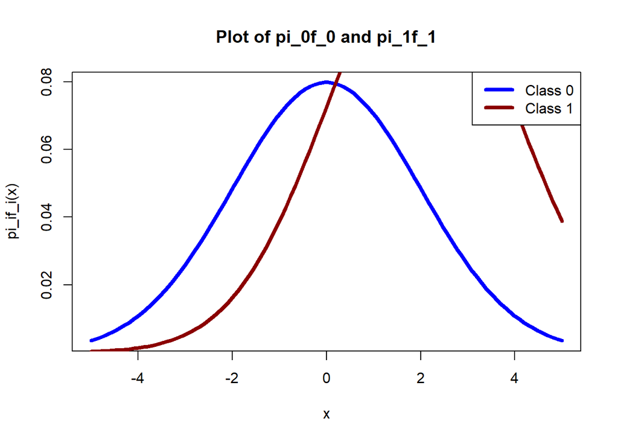

```r
#Plot out the gaussians to see where they should cross (check of math)
x = seq(-5,5,length = 100)
pi_0 = 0.4
pi_1 = 1 - pi_0
mu_0 = 0
mu_1 = 2
sigma_2 = 4

#Define the functions
f_0 = pi_0*dnorm(x,mu_0,sqrt(sigma_2))
f_1 = pi_1*dnorm(x,mu_1,sqrt(sigma_2))

#Plot the curve out.
plot(x,f_0,col = "blue", lwd = 4 ,type  ='l', main = "Plot of pi_0f_0 and pi_1f_1",
     xlab = "x", ylab = "pi_if_i(x)")
#Plot the second curve.
points(x, f_1, col="dark red", lwd = 4, type = 'l')
legend("topright",legend = c("Class 0", "Class 1"),
        col = c("blue","dark red"),lwd = 4,
        text.col = "black",
        horiz = FALSE)
```

```r
numerator = (mu_0^2 - mu_1^2)/(2*sigma_2) + log(pi_1/pi_0)
denominator = (mu_0 - mu_1)/sigma_2
X = numerator/denominator
X
```

```
## [1] 0.1890698
```

This finds the boundary to be 0.1890698. Now, the Bayes error rate is computed as:

$$\pi_0P(X>0.1890698|Y=0) + \pi_1P(X< 0.1890698|Y = 1)$$

```r
#Given the boundary value compute the integral

int_1 = pnorm(X,mu_1,sigma_2)
int_0 = 1 - pnorm(X,mu_0,sigma_2)
error_rate = pi_1*int_1 + pi_0*int_0
error_rate
```

```
## [1] 0.3876824
```